# The Exhibit of American Negroes (1900)

Data, code, and plates from “The Exhibit of American Negroes” at the 1900s Paris Exhibition. W. E. B. Du Bois noted that the purpose of the exhibit was to show: (i) The history of the American Negro, (ii) His present condition, (iii) His education, (iv) His literature.

> “Beneath all this is a carefully thought-out plan, according to which the exhibitors have tried to show: (a) The history of the American Negro. (b) His present condition. (c) His education. (d) His literature.”  
> — W. E. B. Du Bois, *The American Negro at Paris* (1900)

[figure not shown]

[“The Georgia Negro” - Library of Congress](https://www.loc.gov/resource/ppmsca.33893/)

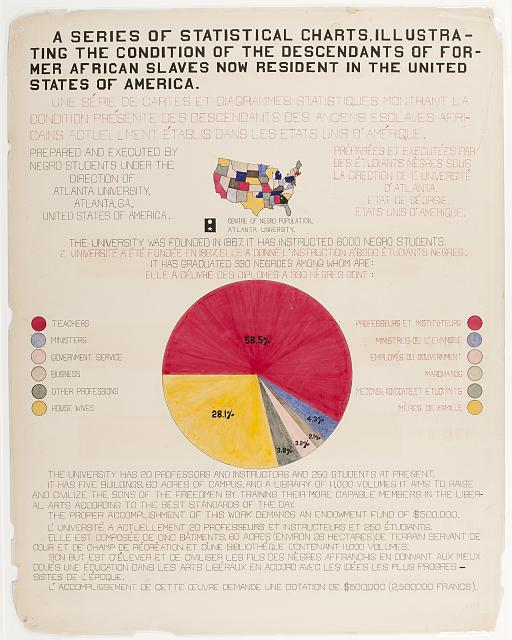

[“A series of statistical charts illustrating the condition of the descendants of former African slaves now in residence in the United States of America” - Library of Congress](https://www.loc.gov/item/2013650365/)

Hi user, this project is still in the works.

For access to data and code, please contact us at quantshopusers [at] gmail [dot] com.